# Fernando_Guerrero_Proyecto_Trade_Ahead_translated

## Trade & Ahead

### About Warrior Bros

I am an IT consultant, who promotes the competitiveness and transformation of organizations from the opportunities presented by technologies and business knowledge, always focus on the value of the human and committed to talent and social development.Therefore, data and information is the most valuable asset of the company and therefore managed with robust and modern tools.Giving solutions oriented to business, sales, finance, human resources, etc.Contemplating the challenges of the new normality.Disruptive and innovative solutions to put companies a step forward in the digital transformation career.

### Context

The Stock Market has consistently came to be a good place to invest in and save for the future.There are a Lot of Compony Reasons to Invest in Stocks.It can Help in Fighting Inflation, Create Wealth, and also provides submail benefits.Good Steady Returns on Investments Over A Long Period of Time Can Also Grow A Lot More than Sems Posable.Also, Thanks to The Power of Compound Interest, The Earlier One Starts Investing, The Larger The Corpus One Can Have For Retirement.Overall, Investing in Stocks Can Help Meet Life 'Financial Aspirations. It's Important to Maininin to Diversified Portfolio When Investing in Stocks in Order to Maximise Earnings under any Market Condition.HAVING A Diversified Portfolio Tends to Yield Higher Returns and Face Lower Risk by Potential Tempering Losses When the Market Is Down.It is ophn easy to get in a manra de Financial metrics to analyze while determining the worth of a stock, and doing the Same for a crowd of stocks to identify the right picks for an individual can be a tedious task.By doing a cluster analysis, One Can Identify Stocks That Exhibit Similar Characteristics and Youch Which Exhibit Minimum Correlation.This Will Help Investors Better Analyze Stocks Across Different Market Segments and Help Protect Against Risks That Could Make The Portfolio Vulnerable to Losses.

### Aim> They have hired me as a data scientist, and they have provided me with data that include the price of the shares and some financial indicators of some companies that quote on the New York Stock Exchange.I have been assigned the tasks of analyzing the data, grouping the actions based on the attributes provided and sharing information about the characteristics of each group.Remembering that Trade & Ahead is a financial consulting firm that provides its customers with personalized investment strategies.

### Data dictionary

- Ticker Symbol: an abbreviation used to uniquely identify the actions that are quoted in the stock market of a particular action in a particular stock market- Company: company name- GICS SECTOR: The specific economic sector assigned to a company by the standard for classification of the global industry (GICS) that best defines its commercial operations- Gics Sub Industry: The specific subindustria group assigned to a company by the Global Industry Classification Standard (GICS) that best defines its commercial operations- Current Price: current price of action in dollars- Price Change: percentage change in the price of shares in 13 weeks- Volatility: Standard deviation of the price of shares in the last 13 weeks- ROE: A measure of financial yield that is calculated by dividing net income from the equity of the shareholders (the equity of the shareholders is equal to the assets of a company except its debt)- Cash Ratio: The relationship between the total cash and equivalent reserves of a company and its total current liabilities.- Net Cash Flow: The difference between the tickets and outputs of a company of a company (in dollars)- Net Inome: Income less expenses, interest and taxes (in dollars)- Earnings Per Share: The net profit of the company divided by the number of ordinary shares it has in circulation (in dollars)- Estimated Shares Outstanding: Company Actions currently held by all its shareholders- P/E Ratio: Relationship between the current price of the company's shares and profits per share- P/B Ratio: Relationship between the price of the shares of the company per share and its book value per share (the book value of a company is the net difference between the total assets and the total liabilities of that company)

```python
# We install the Yellowbrick Library since it was not installed above and we will use it# To obtain the silhouette code and visulumation# With the! pip install plus the library any library is installed!pip install yellowbrick
```

## Import of necessary libraries

```python
# We will begin to load the necessary libraries of Python# Libraries to manipulate the dataimport numpy as np
import pandas as pd

# Libraries for data viewing as graphicsimport matplotlib.pyplot as plt
import seaborn as sns

sns.set_theme(style='darkgrid')

# Eliminates the limit for the number of columns shownpd.set_option("display.max_columns", None)
# Establishes the limit for the number of rows shownpd.set_option("display.max_rows", 200)

# To climb the data using Z-SCOREfrom sklearn.preprocessing import StandardScaler

# To calculate distancesfrom scipy.spatial.distance import cdist, pdist

# To perform the grouping of K-Medias and calculate the silhouette scoresfrom sklearn.cluster import KMeans
from sklearn.metrics import silhouette_score

# To visualize the elbow curve and silhouette scoresfrom yellowbrick.cluster import KElbowVisualizer, SilhouetteVisualizer

# To perform a hierarchical grouping, calculate the cofenetic correlation and create dendrogramsfrom sklearn.cluster import AgglomerativeClustering
from scipy.cluster.hierarchy import dendrogram, linkage, cophenet

# To suppress warningsimport warnings
warnings.filterwarnings("ignore")
```

## We import the data set

```python
# We load the data of the Trade & Ahead, which was provided to usdata = pd.read_csv('stock_data.csv')
```

### We visualize the first and last 5 rows of the data set

```python
# We show the first 5 rows of the data setdata.head()
```

|  | Ticker Symbol | Security | GICS Sector | GICS Sub Industry | Current Price | Price Change | Volatility | ROE | Cash Ratio | Net Cash Flow | Net Income | Earnings Per Share | Estimated Shares Outstanding | P/E Ratio | P/B Ratio |
| --- | --- | --- | --- | --- | --- | --- | --- | --- | --- | --- | --- | --- | --- | --- | --- |
| 0 | AAL | American Airlines Group | Industrials | Airlines | 42.349998 | 9.999995 | 1.687151 | 135 | 51 | -604000000 | 7610000000 | 11.39 | 6.681299e+08 | 3.718174 | -8.784219 |
| 1 | ABBV | AbbVie | Health Care | Pharmaceuticals | 59.240002 | 8.339433 | 2.197887 | 130 | 77 | 51000000 | 5144000000 | 3.15 | 1.633016e+09 | 18.806350 | -8.750068 |
| 2 | ABT | Abbott Laboratories | Health Care | Health Care Equipment | 44.910000 | 11.301121 | 1.273646 | 21 | 67 | 938000000 | 4423000000 | 2.94 | 1.504422e+09 | 15.275510 | -0.394171 |
| 3 | ADBE | Adobe Systems Inc | Information Technology | Application Software | 93.940002 | 13.977195 | 1.357679 | 9 | 180 | -240840000 | 629551000 | 1.26 | 4.996437e+08 | 74.555557 | 4.199651 |
| 4 | ADI | Analog Devices, Inc. | Information Technology | Semiconductors | 55.320000 | -1.827858 | 1.701169 | 14 | 272 | 315120000 | 696878000 | 0.31 | 2.247994e+09 | 178.451613 | 1.059810 |

```python
# We show the last 5 rows of the data setdata.tail()
```

|  | Ticker Symbol | Security | GICS Sector | GICS Sub Industry | Current Price | Price Change | Volatility | ROE | Cash Ratio | Net Cash Flow | Net Income | Earnings Per Share | Estimated Shares Outstanding | P/E Ratio | P/B Ratio |
| --- | --- | --- | --- | --- | --- | --- | --- | --- | --- | --- | --- | --- | --- | --- | --- |
| 335 | YHOO | Yahoo Inc. | Information Technology | Internet Software & Services | 33.259998 | 14.887727 | 1.845149 | 15 | 459 | -1032187000 | -4359082000 | -4.64 | 939457327.6 | 28.976191 | 6.261775 |
| 336 | YUM | Yum! Brands Inc | Consumer Discretionary | Restaurants | 52.516175 | -8.698917 | 1.478877 | 142 | 27 | 159000000 | 1293000000 | 2.97 | 435353535.4 | 17.682214 | -3.838260 |
| 337 | ZBH | Zimmer Biomet Holdings | Health Care | Health Care Equipment | 102.589996 | 9.347683 | 1.404206 | 1 | 100 | 376000000 | 147000000 | 0.78 | 188461538.5 | 131.525636 | -23.884449 |
| 338 | ZION | Zions Bancorp | Financials | Regional Banks | 27.299999 | -1.158588 | 1.468176 | 4 | 99 | -43623000 | 309471000 | 1.20 | 257892500.0 | 22.749999 | -0.063096 |
| 339 | ZTS | Zoetis | Health Care | Pharmaceuticals | 47.919998 | 16.678836 | 1.610285 | 32 | 65 | 272000000 | 339000000 | 0.68 | 498529411.8 | 70.470585 | 1.723068 |

```python
# With Shape we observe the number of rows and columns of the data or databasedata.shape
```

```
(340, 15)
```

- There are 340 lines and 15 columns in the data set or database

### showing some rows of the data set

```python
# Let's see a sample of the data otherwise with the Sample Commanddata.sample(n=10, random_state=1)
```

|  | Ticker Symbol | Security | GICS Sector | GICS Sub Industry | Current Price | Price Change | Volatility | ROE | Cash Ratio | Net Cash Flow | Net Income | Earnings Per Share | Estimated Shares Outstanding | P/E Ratio | P/B Ratio |
| --- | --- | --- | --- | --- | --- | --- | --- | --- | --- | --- | --- | --- | --- | --- | --- |
| 102 | DVN | Devon Energy Corp. | Energy | Oil & Gas Exploration & Production | 32.000000 | -15.478079 | 2.923698 | 205 | 70 | 830000000 | -14454000000 | -35.55 | 4.065823e+08 | 93.089287 | 1.785616 |
| 125 | FB | Facebook | Information Technology | Internet Software & Services | 104.660004 | 16.224320 | 1.320606 | 8 | 958 | 592000000 | 3669000000 | 1.31 | 2.800763e+09 | 79.893133 | 5.884467 |
| 11 | AIV | Apartment Investment & Mgmt | Real Estate | REITs | 40.029999 | 7.578608 | 1.163334 | 15 | 47 | 21818000 | 248710000 | 1.52 | 1.636250e+08 | 26.335526 | -1.269332 |
| 248 | PG | Procter & Gamble | Consumer Staples | Personal Products | 79.410004 | 10.660538 | 0.806056 | 17 | 129 | 160383000 | 636056000 | 3.28 | 4.913916e+08 | 24.070121 | -2.256747 |
| 238 | OXY | Occidental Petroleum | Energy | Oil & Gas Exploration & Production | 67.610001 | 0.865287 | 1.589520 | 32 | 64 | -588000000 | -7829000000 | -10.23 | 7.652981e+08 | 93.089287 | 3.345102 |
| 336 | YUM | Yum! Brands Inc | Consumer Discretionary | Restaurants | 52.516175 | -8.698917 | 1.478877 | 142 | 27 | 159000000 | 1293000000 | 2.97 | 4.353535e+08 | 17.682214 | -3.838260 |
| 112 | EQT | EQT Corporation | Energy | Oil & Gas Exploration & Production | 52.130001 | -21.253771 | 2.364883 | 2 | 201 | 523803000 | 85171000 | 0.56 | 1.520911e+08 | 93.089287 | 9.567952 |
| 147 | HAL | Halliburton Co. | Energy | Oil & Gas Equipment & Services | 34.040001 | -5.101751 | 1.966062 | 4 | 189 | 7786000000 | -671000000 | -0.79 | 8.493671e+08 | 93.089287 | 17.345857 |
| 89 | DFS | Discover Financial Services | Financials | Consumer Finance | 53.619999 | 3.653584 | 1.159897 | 20 | 99 | 2288000000 | 2297000000 | 5.14 | 4.468872e+08 | 10.431906 | -0.375934 |
| 173 | IVZ | Invesco Ltd. | Financials | Asset Management & Custody Banks | 33.480000 | 7.067477 | 1.580839 | 12 | 67 | 412000000 | 968100000 | 2.26 | 4.283628e+08 | 14.814159 | 4.218620 |

### Checking the data types of columns for the data set

```python
# With the info method we display the data types in the data setdata.info()
```

```
<class 'pandas.core.frame.DataFrame'>
RangeIndex: 340 entries, 0 to 339
Data columns (total 15 columns):
 #   Column                        Non-Null Count  Dtype
---  ------                        --------------  -----
 0   Ticker Symbol                 340 non-null    object
 1   Security                      340 non-null    object
 2   GICS Sector                   340 non-null    object
 3   GICS Sub Industry             340 non-null    object
 4   Current Price                 340 non-null    float64
 5   Price Change                  340 non-null    float64
 6   Volatility                    340 non-null    float64
 7   ROE                           340 non-null    int64
 8   Cash Ratio                    340 non-null    int64
 9   Net Cash Flow                 340 non-null    int64
 10  Net Income                    340 non-null    int64
 11  Earnings Per Share            340 non-null    float64
 12  Estimated Shares Outstanding  340 non-null    float64
 13  P/E Ratio                     340 non-null    float64
 14  P/B Ratio                     340 non-null    float64
dtypes: float64(7), int64(4), object(4)
memory usage: 40.0+ KB
```

- The columns of: Current Price, Price Change, Volatility, Earnings Per Share, Estimated Shares Outstanding,P/e ratio, p/b ratio are float type (decimal).- The columns of Roe, Cash Ratio, Net Cash Flow and Net Inome are entirely.- The rest of the columns are of the type of object data (string).

### Creation of a copy of the original data

```python
# We copy the data to another variable, called DF, to avoid changes in the original datadf = data.copy()
```

### We check duplicate data and/or missing values

```python
# We verify if there are duplicate values in the data, with the duplicated method and the SUM methoddf.duplicated().sum()
```

```
0
```

- There are no duplicate data in the database or data cuning

```python
# We verify if there are missing values in the data, with the ISNULL method and the SUM methoddf.isnull().sum()
```

```
Ticker Symbol                   0
Security                        0
GICS Sector                     0
GICS Sub Industry               0
Current Price                   0
Price Change                    0
Volatility                      0
ROE                             0
Cash Ratio                      0
Net Cash Flow                   0
Net Income                      0
Earnings Per Share              0
Estimated Shares Outstanding    0
P/E Ratio                       0
P/B Ratio                       0
dtype: int64
```

```python
# We verify if there are missing values in the data, with the ISNA method and the Sum Methoddf.isna().sum()
```

```
Ticker Symbol                   0
Security                        0
GICS Sector                     0
GICS Sub Industry               0
Current Price                   0
Price Change                    0
Volatility                      0
ROE                             0
Cash Ratio                      0
Net Cash Flow                   0
Net Income                      0
Earnings Per Share              0
Estimated Shares Outstanding    0
P/E Ratio                       0
P/B Ratio                       0
dtype: int64
```

- There are no missing values in the data or in the database

### Statistical summary of the data set

**Let's look at the statistical summary of the data.**

```python
# With the describes method it helps us to see a statistical summary of the datadf.describe().T
```

|  | count | mean | std | min | 25% | 50% | 75% | max |
| --- | --- | --- | --- | --- | --- | --- | --- | --- |
| Current Price | 340.0 | 8.086234e+01 | 9.805509e+01 | 4.500000e+00 | 3.855500e+01 | 5.970500e+01 | 9.288000e+01 | 1.274950e+03 |
| Price Change | 340.0 | 4.078194e+00 | 1.200634e+01 | -4.712969e+01 | -9.394838e-01 | 4.819505e+00 | 1.069549e+01 | 5.505168e+01 |
| Volatility | 340.0 | 1.525976e+00 | 5.917984e-01 | 7.331632e-01 | 1.134878e+00 | 1.385593e+00 | 1.695549e+00 | 4.580042e+00 |
| ROE | 340.0 | 3.959706e+01 | 9.654754e+01 | 1.000000e+00 | 9.750000e+00 | 1.500000e+01 | 2.700000e+01 | 9.170000e+02 |
| Cash Ratio | 340.0 | 7.002353e+01 | 9.042133e+01 | 0.000000e+00 | 1.800000e+01 | 4.700000e+01 | 9.900000e+01 | 9.580000e+02 |
| Net Cash Flow | 340.0 | 5.553762e+07 | 1.946365e+09 | -1.120800e+10 | -1.939065e+08 | 2.098000e+06 | 1.698108e+08 | 2.076400e+10 |
| Net Income | 340.0 | 1.494385e+09 | 3.940150e+09 | -2.352800e+10 | 3.523012e+08 | 7.073360e+08 | 1.899000e+09 | 2.444200e+10 |
| Earnings Per Share | 340.0 | 2.776662e+00 | 6.587779e+00 | -6.120000e+01 | 1.557500e+00 | 2.895000e+00 | 4.620000e+00 | 5.009000e+01 |
| Estimated Shares Outstanding | 340.0 | 5.770283e+08 | 8.458496e+08 | 2.767216e+07 | 1.588482e+08 | 3.096751e+08 | 5.731175e+08 | 6.159292e+09 |
| P/E Ratio | 340.0 | 3.261256e+01 | 4.434873e+01 | 2.935451e+00 | 1.504465e+01 | 2.081988e+01 | 3.176476e+01 | 5.280391e+02 |
| P/B Ratio | 340.0 | -1.718249e+00 | 1.396691e+01 | -7.611908e+01 | -4.352056e+00 | -1.067170e+00 | 3.917066e+00 | 1.290646e+02 |

## Exploratory data analysis

### Univariate analysis

```python
# We create the following function to draw a cash diagram and a histogram along the same scale.

def histogram_boxplot(df, feature, figsize=(12, 7), kde=False, bins=None):
    """
    Boxplot and histogram combined

    data: dataframe
    feature: dataframe column
    figsize: size of figure (default (12,7))
    kde: whether to the show density curve (default False)
    bins: number of bins for histogram (default None)
    """
    f2, (ax_box2, ax_hist2) = plt.subplots(
        nrows=2,  # Número de filas de la cuadrícula de la subparcela = 2
        sharex=True,  # el eje x se compartirá entre todas las subparcelas
        gridspec_kw={"height_ratios": (0.25, 0.75)},
        figsize=figsize,
    )   # creando las 2 subplots
    sns.boxplot(
        data=df, x=feature, ax=ax_box2, showmeans=True, color="violet"
    )   # se creará un diagrama de caja y un triángulo indicará el valor medio de la columna
    sns.histplot(
        data=df, x=feature, kde=kde, ax=ax_hist2, bins=bins, palette="winter"
    ) if bins else sns.histplot(
        data=df, x=feature, kde=kde, ax=ax_hist2
    )  # para histogram
    ax_hist2.axvline(
        df[feature].mean(), color="green", linestyle="--"
    )  # Añadiendo la media al histogram
    ax_hist2.axvline(
        df[feature].median(), color="black", linestyle="-"
    )  # Añadiendo la mediana al histogram
```

**`Current Price`**

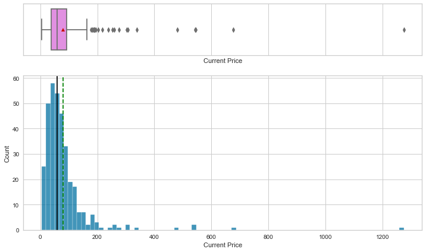

```python
# We use the history histogra_boxploot to graph the "Current Price"histogram_boxplot(df, 'Current Price')
```

**`Price Change`**

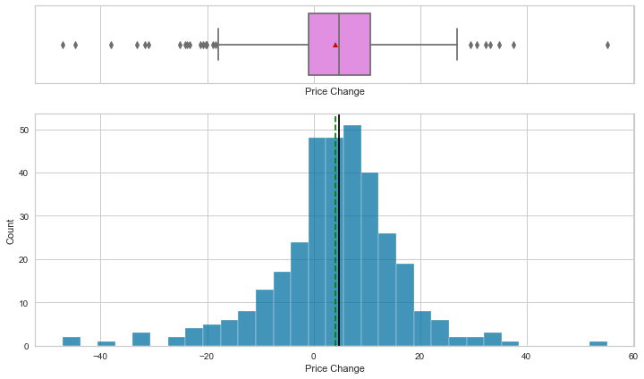

```python
# We use the history histogra_boxploot to graph the "Price Change"histogram_boxplot(df, 'Price Change')
```

- Price Change is almost on the average line, being an indicator that the price does not change so often

**`Volatility`**

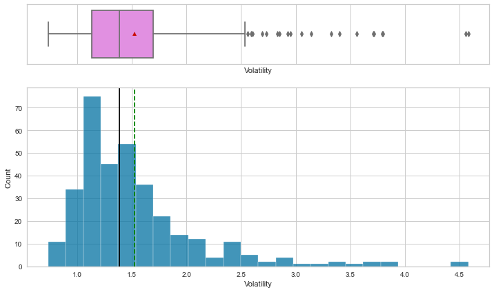

```python
# We use the history histogra_boxploot to graph the "volatility"histogram_boxplot(df,'Volatility')
```

- The volatility is slightly biased to the right, indicating that there is a certain volatibility in the market

**`ROE`**

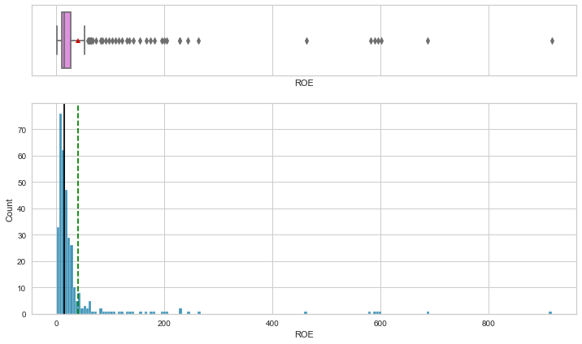

```python
# We use the Histograph_Boxploot function to graph the "roe"histogram_boxplot(df,'ROE')
```

**`Cash Ratio`**

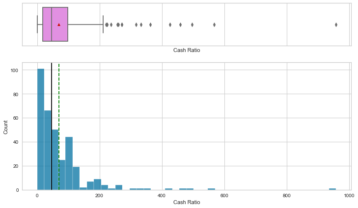

```python
# We use the histogra_boxploot function to graph the "Cash Ratio"histogram_boxplot(df,'Cash Ratio')
```

**`net cash flow`**

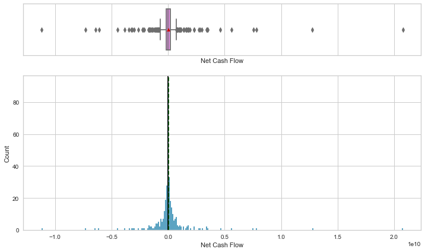

```python
# We use the Histograph_Boxploot function to graph the "Net Cash Flow"histogram_boxplot(df,'Net Cash Flow')
```

- Net cash flow practically on the middle line, being a respite to deal with payments in the future

**`net Inome`**

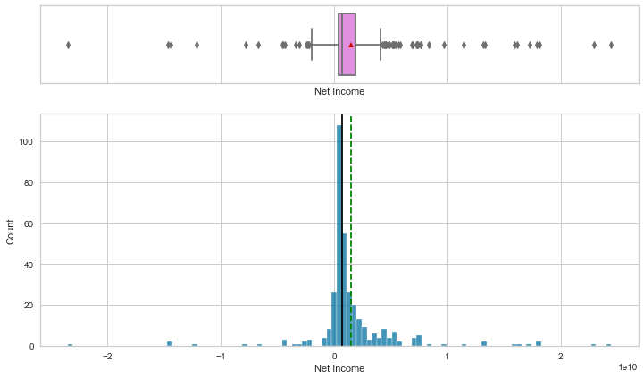

```python
# We use the histogra_boxploot function to graph the "net income"histogram_boxplot(df,'Net Income')
```

- Net Inome almost on the average line being that you can't see as many profits as expected.

**`EARNINGS PER SHARE`**

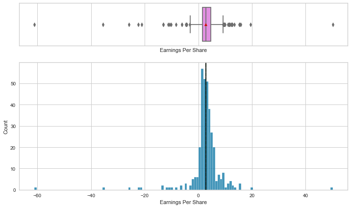

```python
# We use the histogra_boxploot function to graph the "Earnings Per Share"histogram_boxplot(df,'Earnings Per Share')
```

- Earnings per share being on the median, it means that you can see a light one in the benefit by action

**`ESTID SHARES OUTSTANDING`**

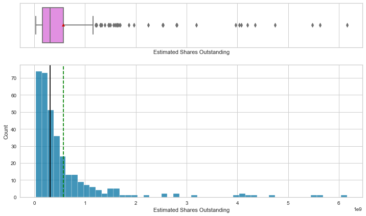

```python
# We use the history histogra_boxploot to graph the "Estimated Shares Outstanding"histogram_boxplot(df,'Estimated Shares Outstanding')
```

**`p/e ratio`**

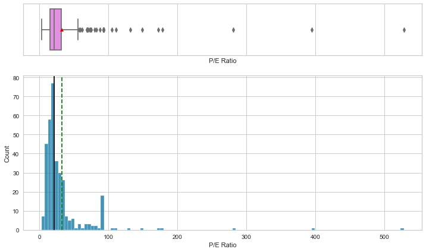

```python
# We use the history histogra_boxploot to graph the "p/e ratio"histogram_boxplot(df,'P/E Ratio')
```

- P/E Ratio Good The net profit of the shares are not so much in their price.

**`p/b ratio`**

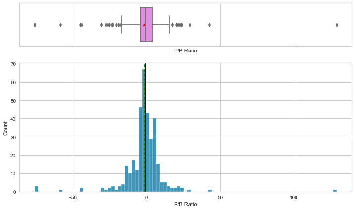

```python
# We use the histogra_boxploot function to graph the "p/b ratio"histogram_boxplot(df,'P/B Ratio')
```

- P/B ratio The net profit between the price of the action is 50 and 50.

```python
# Function to create barloot diagrams
def labeled_barplot(df, feature, perc=False, n=None):
    """
    Barplot with percentage at the top

    data: dataframe
    feature: dataframe column
    perc: whether to display percentages instead of count (default is False)
    n: displays the top n category levels (default is None, i.e., display all levels)
    """

    total = len(df[feature])   # longitud de la columna
    count = df[feature].nunique()
    if n is None:
        plt.figure(figsize=(count + 1, 5))
    else:
        plt.figure(figsize=(n + 1, 5))

    plt.xticks(rotation=90, fontsize=15)
    ax = sns.countplot(
        data=df,
        x=feature,
        palette="Paired",
        order=df[feature].value_counts().index[:n].sort_values(),
    )

    for p in ax.patches:
        if perc == True:
            label = "{:.1f}%".format(
                100 * p.get_height() / total
            )   # porcentaje de cada clase de la categoría
        else:
            label = p.get_height()   # recuento de cada nivel de la categoría

        x = p.get_x() + p.get_width() / 2    # ancho del plot
        y = p.get_height()  # largo del plot

        ax.annotate(
            label,
            (x, y),
            ha="center",
            va="center",
            size=12,
            xytext=(0, 5),
            textcoords="offset points",
        )  # anotar el porcentaje

    plt.show()  # se muestra el plot
```

**`Gics Sector`**

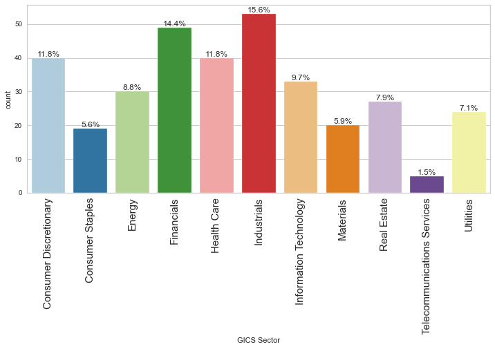

```python
# We use the function defined in the previous step to graph "Gics Sector"labeled_barplot(df, 'GICS Sector', perc=True)
```

- Gics Sector, the best economic sector given its operations, is industial and financial, followed by health and discretionary consumer

**`Gics Sub Industry`**

[figure not shown]

```python
# We use the function defined in the previous step to graph "Gics Sub Industry"labeled_barplot(df, 'GICS Sub Industry', perc=True)
```

- Gics Sub Industry, the best subindustria group is oil and gas, followed by the reits.

### Bivariate analysis

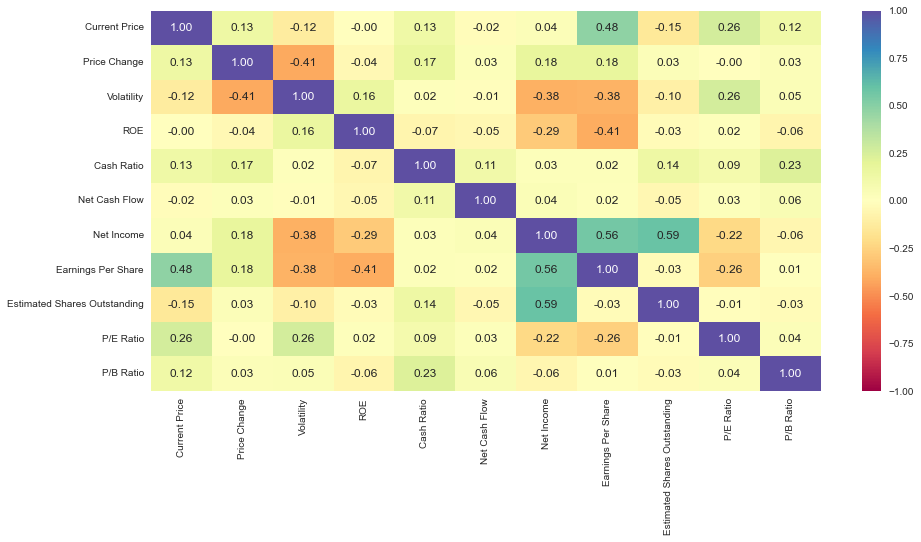

```python
# We check the correlation between variablesplt.figure(figsize=(15, 7))
sns.heatmap(
    df.corr(), annot=True, vmin=-1, vmax=1, fmt=".2f", cmap="Spectral"
)
plt.show()
```

- There is correlation between net income with earnings per share and estimated Shares outstanding, in addition toEarnings Per Share with Current Price.

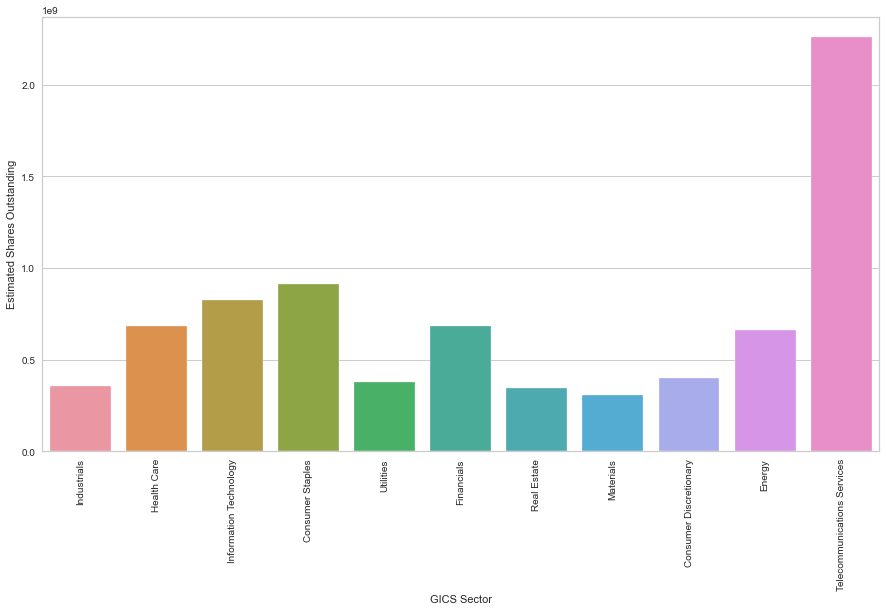

```python
plt.figure(figsize=(15,8))
sns.barplot(data=df, x='GICS Sector', y='Estimated Shares Outstanding', ci=False)
plt.xticks(rotation=90)
plt.show()
```

- The actions in the telecommunications services sector are held by the shareholders, but the actions of materials are those that have less power of the shareholders

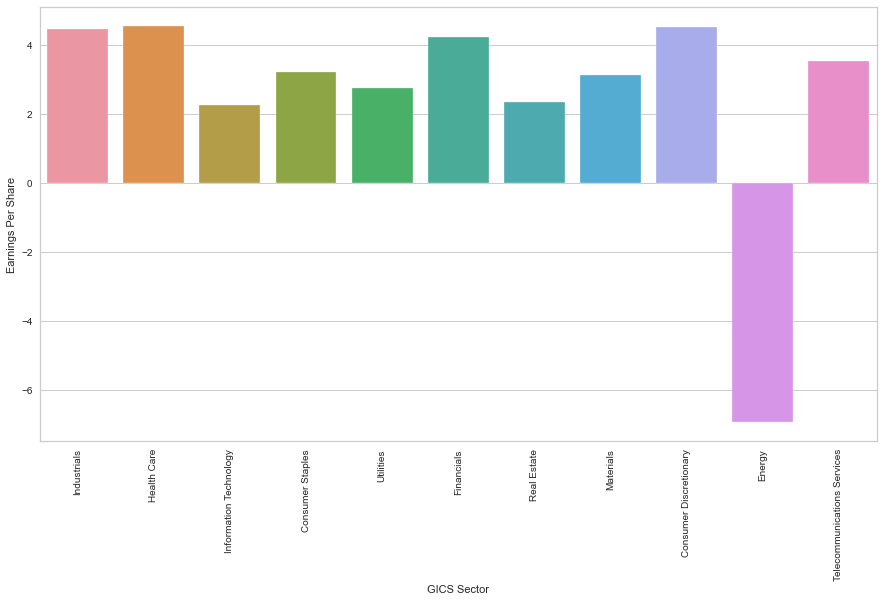

```python
plt.figure(figsize=(15,8))
sns.barplot(data=df, x='GICS Sector', y='Earnings Per Share', ci=False)
plt.xticks(rotation=90)
plt.show()
```

- Energy is the net profit of the company with less number of ordinary shares that are in circulation

**P/E relations can help determine the relative value of the shares of a company, since they represent the amount of money that an investor is willing to invest in a single action of a company for each dollar of their profits.Let's see how the P/E relationship varies, on average, between economic sectors.**

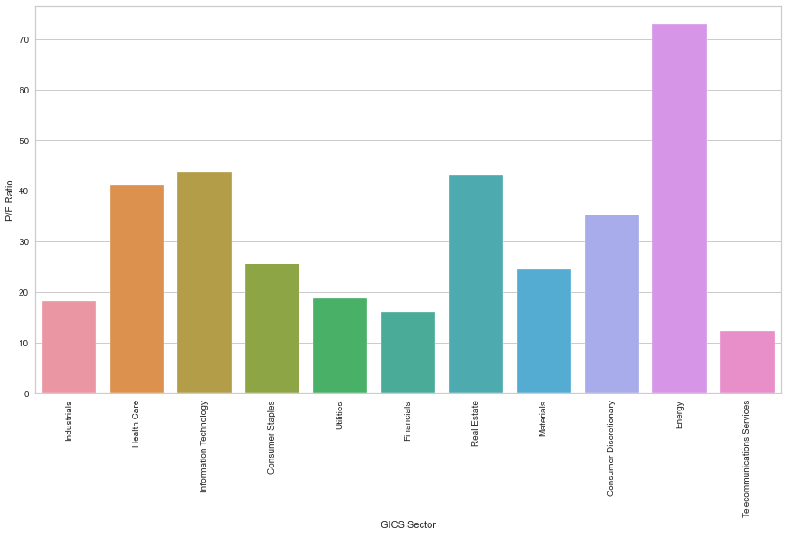

```python
plt.figure(figsize=(15,8))
sns.barplot(data=df, x='GICS Sector', y='P/E Ratio', ci=False)
plt.xticks(rotation=90)
plt.show()
```

- The energy sector has less net profit given the price of shares

**Volatility explains fluctuation in the price of shares.An action with high volatility will experience more abrupt price changes, which makes it a more risky investment.Let's see how volatility varies, on average, between economic sectors.**

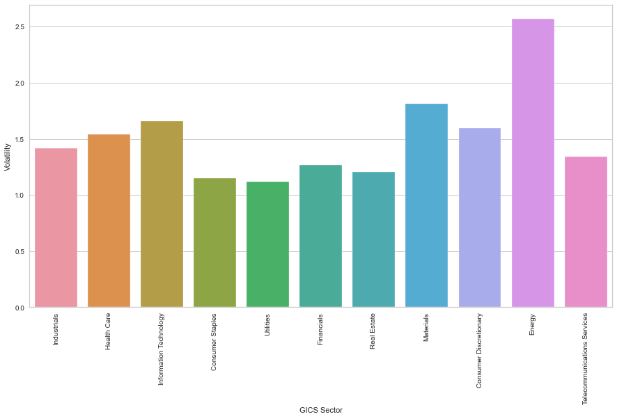

```python
plt.figure(figsize=(15,8))
sns.barplot(data=df, x='GICS Sector', y='Volatility', ci=False)
plt.xticks(rotation=90)
plt.show()
```

- The energy sector has greater volatibility

## Data preprocessing

### Checking of atypical values

- We trace the cash diagrams of all numerical columns to verify if there are atypical values.

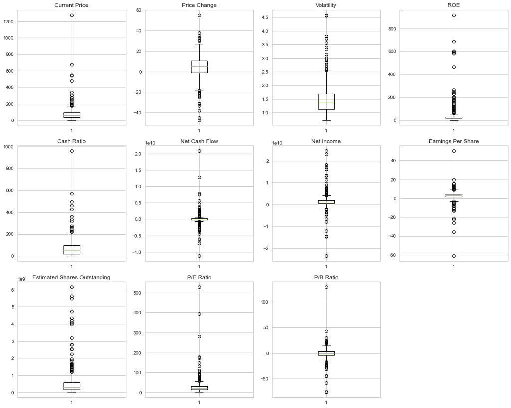

```python
# detection of atypical values with boxplootplt.figure(figsize=(15, 12))
numeric_columns = df.select_dtypes(include=np.number).columns.tolist()

for i, variable in enumerate(numeric_columns):
    plt.subplot(3, 4, i + 1)
    plt.boxplot(df[variable], whis=1.5)
    plt.tight_layout()
    plt.title(variable)

plt.show()
```

### scaling

- Let's climb the data before proceeding with the group.

```python
# We climb the data before the groupscaler = StandardScaler()
subset = df[numeric_columns].copy()
subset_scaled = scaler.fit_transform(subset)
```

```python
# We create a scalled data data framesubset_scaled_df = pd.DataFrame(subset_scaled, columns=subset.columns)
```

## K-Means Group

### Checking the elbow diagram

```python
# We create the variable K_means_df and leave the value of the subset in this variablek_means_df = subset_scaled_df.copy()
```

```
Numero de Clusteres: 1 	 Distorsión promedio: 2.5425069919221697
Numero de Clusteres: 2 	 Distorsión promedio: 2.382318498894466
Numero de Clusteres: 3 	 Distorsión promedio: 2.2692367155390745
Numero de Clusteres: 4 	 Distorsión promedio: 2.1745559827866363
Numero de Clusteres: 5 	 Distorsión promedio: 2.128799332840716
Numero de Clusteres: 6 	 Distorsión promedio: 2.080400099226289
Numero de Clusteres: 7 	 Distorsión promedio: 2.0289794220177395
Numero de Clusteres: 8 	 Distorsión promedio: 1.964144163389972
Numero de Clusteres: 9 	 Distorsión promedio: 1.9221492045198068
Numero de Clusteres: 10 	 Distorsión promedio: 1.8513913649973124
Numero de Clusteres: 11 	 Distorsión promedio: 1.8024134734578485
Numero de Clusteres: 12 	 Distorsión promedio: 1.7900931879652673
Numero de Clusteres: 13 	 Distorsión promedio: 1.7417609203336912
Numero de Clusteres: 14 	 Distorsión promedio: 1.673559857259703
```

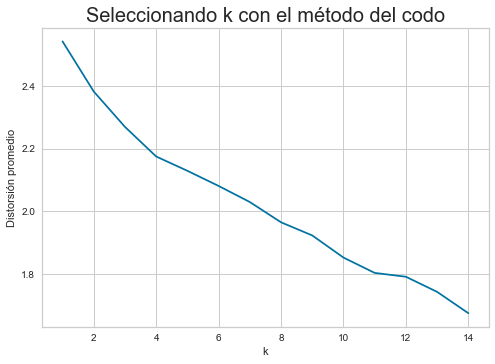

```python
# The following code line indicates the number of expected clusters (14)clusters = range(1, 15)
meanDistortions = []

for k in clusters:
    model = KMeans(n_clusters=k, random_state=1)
    model.fit(subset_scaled_df)
    prediction = model.predict(k_means_df)
    distortion = (
        sum(np.min(cdist(k_means_df, model.cluster_centers_, "euclidean"), axis=1))
        / k_means_df.shape[0]
    )

    meanDistortions.append(distortion)

    print("Numero de Clusteres:", k, "\t Distorsión promedio:", distortion)

plt.plot(clusters, meanDistortions, "bx-")
plt.xlabel("k")
plt.ylabel("Distorsión promedio")
plt.title("Seleccionando k con el método del codo", fontsize=20)
plt.show()
```

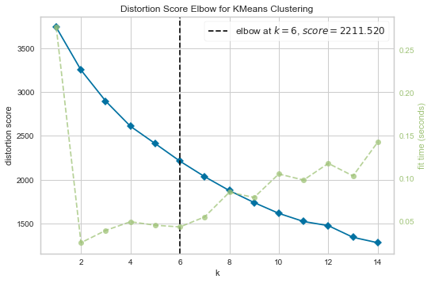

```python
model = KMeans(random_state=1)
visualizer = KElbowVisualizer(model, k=(1, 15), timings=True)
visualizer.fit(k_means_df)  # ajustando los datos al visualizador
visualizer.show()  # finalizando y renderizando la figura
```

### Let's look at the silhouettes scores

```
Para n_clusters = 2, la puntuación de la silueta es 0.43969639509980457)
Para n_clusters = 3, la puntuación de la silueta es 0.4644405674779404)
Para n_clusters = 4, la puntuación de la silueta es 0.4577225970476733)
Para n_clusters = 5, la puntuación de la silueta es 0.43228336443659804)
Para n_clusters = 6, la puntuación de la silueta es 0.4005422737213617)
Para n_clusters = 7, la puntuación de la silueta es 0.3976335364987305)
Para n_clusters = 8, la puntuación de la silueta es 0.40278401969450467)
Para n_clusters = 9, la puntuación de la silueta es 0.3778585981433699)
Para n_clusters = 10, la puntuación de la silueta es 0.13458938329968687)
Para n_clusters = 11, la puntuación de la silueta es 0.1421832155528444)
Para n_clusters = 12, la puntuación de la silueta es 0.2044669621527429)
Para n_clusters = 13, la puntuación de la silueta es 0.23424874810104204)
Para n_clusters = 14, la puntuación de la silueta es 0.12102526472829901)
```

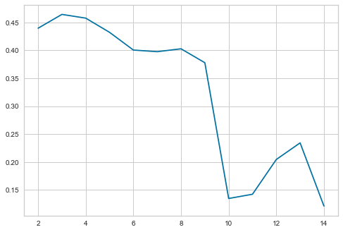

```python
sil_score = []
cluster_list = range(2, 15)
for n_clusters in cluster_list:
    clusterer = KMeans(n_clusters=n_clusters, random_state=1)
    preds = clusterer.fit_predict((subset_scaled_df))
    score = silhouette_score(k_means_df, preds)
    sil_score.append(score)
    print("Para n_clusters = {}, la puntuación de la silueta es {})".format(n_clusters, score))

plt.plot(cluster_list, sil_score)
plt.show()
```

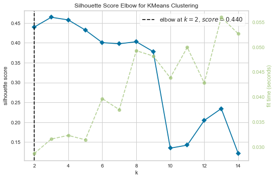

```python
model = KMeans(random_state=1)
visualizer = KElbowVisualizer(model, k=(2, 15), metric="silhouette", timings=True)
visualizer.fit(k_means_df)  # ajustando los datos al visualizador
visualizer.show()  # finalizando y renderizando la figura
```

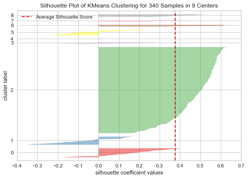

```python
# finding the optimal number of conglomerates with silhouette coefficientsvisualizer = SilhouetteVisualizer(KMeans(9, random_state=1))
visualizer.fit(k_means_df)
visualizer.show()
```

### Creation of the final model

```python
# Final Model K-Meanskmeans = KMeans(n_clusters=9, random_state=1)
kmeans.fit(k_means_df)
```

```
KMeans(n_clusters=9, random_state=1)
```

```python
# Creating a copy of the original datadf1 = df.copy()
# Adding Kmeans cluster tags to original and scalled data framesk_means_df["KM_segments"] = kmeans.labels_
df1["KM_segments"] = kmeans.labels_
```

### Generation of cluster profiles

```python
km_cluster_profile = df1.groupby("KM_segments").mean()
```

```python
km_cluster_profile["count_in_each_segment"] = (
    df1.groupby("KM_segments")["Security"].count().values  ## agrupamos por las etiquetas del clúster
)
```

```python
km_cluster_profile.style.highlight_max(color="lightgreen", axis=0)
```

| KM_segments | Current Price | Price Change | Volatility | ROE | Cash Ratio | Net Cash Flow | Net Income | Earnings Per Share | Estimated Shares Outstanding | P/E Ratio | P/B Ratio | count_in_each_segment |
| --- | --- | --- | --- | --- | --- | --- | --- | --- | --- | --- | --- | --- |
| 0 | 34.558104 | -15.284918 | 2.811494 | 41.037037 | 46.074074 | -222747814.814815 | -1884359259.259259 | -4.857778 | 496264493.701482 | 72.688430 | 1.575281 | 27 |
| 1 | 162.710972 | 12.513141 | 1.814490 | 25.916667 | 291.375000 | 45246250.000000 | 875603458.333333 | 4.210833 | 606112438.106250 | 45.063231 | 15.624694 | 24 |
| 2 | 71.926700 | 5.141277 | 1.376998 | 25.071146 | 50.513834 | -63178118.577075 | 1327588067.193676 | 3.623439 | 402120917.453399 | 23.544967 | -3.316284 | 253 |
| 3 | 26.990000 | -14.060688 | 3.296307 | 603.000000 | 57.333333 | -585000000.000000 | -17555666666.666668 | -39.726667 | 481910081.666667 | 71.528835 | 1.638633 | 3 |
| 4 | 1274.949951 | 3.190527 | 1.268340 | 29.000000 | 184.000000 | -1671386000.000000 | 2551360000.000000 | 50.090000 | 50935516.070000 | 25.453183 | -1.052429 | 1 |
| 5 | 73.324375 | 4.604377 | 1.209719 | 31.875000 | 93.875000 | 4587600000.000000 | 7601768750.000000 | 5.467187 | 1565096943.725000 | 21.062418 | -0.253326 | 16 |
| 6 | 108.304002 | 10.737770 | 1.165694 | 566.200000 | 26.600000 | -278760000.000000 | 687180000.000000 | 1.548000 | 349607057.720000 | 34.898915 | -16.851358 | 5 |
| 7 | 327.006671 | 21.917380 | 2.029752 | 4.000000 | 106.000000 | 698240666.666667 | 287547000.000000 | 0.750000 | 366763235.300000 | 400.989188 | -5.322376 | 3 |
| 8 | 50.744999 | 5.512605 | 1.070356 | 24.875000 | 60.250000 | -3860125000.000000 | 15782875000.000000 | 3.632500 | 4640082627.625000 | 16.598649 | -7.787061 | 8 |

- Viewing the different clusters in the different segments in all variables we see that:- Cluster 8 has greater Net Inome, estimated Shares outstanding.It means that they have greater net income and better powerAbout actions

```python
## We print the companies of each clusterfor cl in df1["KM_segments"].unique():
    print("In cluster {}, Las siguientes empresas están presentes:".format(cl))
    print(df1[df1["KM_segments"] == cl]["Security"].unique())
    print()
```

```
In cluster 2, Las siguientes empresas están presentes:
['American Airlines Group' 'AbbVie' 'Abbott Laboratories'
 'Archer-Daniels-Midland Co' 'Ameren Corp' 'American Electric Power'
 'AFLAC Inc' 'American International Group, Inc.'
 'Apartment Investment & Mgmt' 'Assurant Inc' 'Arthur J. Gallagher & Co.'
 'Akamai Technologies Inc' 'Albemarle Corp' 'Alaska Air Group Inc'
 'Allstate Corp' 'Applied Materials Inc' 'AMETEK Inc'
 'Affiliated Managers Group Inc' 'Ameriprise Financial'
 'American Tower Corp A' 'AutoNation Inc' 'Anthem Inc.' 'Aon plc'
 'Amphenol Corp' 'Activision Blizzard' 'AvalonBay Communities, Inc.'
 'American Water Works Company Inc' 'American Express Co' 'Boeing Company'
 'Baxter International Inc.' 'BB&T Corporation' 'Bard (C.R.) Inc.'
 'The Bank of New York Mellon Corp.' 'Ball Corp' 'Bristol-Myers Squibb'
 'Boston Scientific' 'BorgWarner' 'Boston Properties' 'Caterpillar Inc.'
 'Chubb Limited' 'CBRE Group' 'Crown Castle International Corp.'
 'Carnival Corp.' 'Citizens Financial Group' 'Church & Dwight'
 'C. H. Robinson Worldwide' 'CIGNA Corp.' 'Cincinnati Financial'
 'Comerica Inc.' 'CME Group Inc.' 'Cummins Inc.' 'CMS Energy'
 'Centene Corporation' 'CenterPoint Energy' 'Capital One Financial'
 'The Cooper Companies' 'CSX Corp.' 'CenturyLink Inc'
 'Cognizant Technology Solutions' 'Citrix Systems' 'CVS Health'
 'Chevron Corp.' 'Dominion Resources' 'Delta Air Lines' 'Du Pont (E.I.)'
 'Deere & Co.' 'Discover Financial Services' 'Quest Diagnostics'
 'Danaher Corp.' 'Discovery Communications-A' 'Discovery Communications-C'
 'Delphi Automotive' 'Digital Realty Trust' 'Dun & Bradstreet'
 'Dover Corp.' 'Dr Pepper Snapple Group' 'Duke Energy' 'DaVita Inc.'
 'Ecolab Inc.' 'Consolidated Edison' 'Equifax Inc.' "Edison Int'l"
 'Eastman Chemical' 'Equity Residential' 'Eversource Energy'
 'Essex Property Trust, Inc.' 'E*Trade' 'Eaton Corporation'
 'Entergy Corp.' "Expeditors Int'l" 'Expedia Inc.' 'Extra Space Storage'
 'Fastenal Co' 'Fortune Brands Home & Security' 'FirstEnergy Corp'
 'Fidelity National Information Services' 'Fiserv Inc' 'FLIR Systems'
 'Fluor Corp.' 'Flowserve Corporation' 'FMC Corporation'
 'Federal Realty Investment Trust' 'General Dynamics'
 'General Growth Properties Inc.' 'Corning Inc.' 'General Motors'
 'Genuine Parts' 'Garmin Ltd.' 'Goodyear Tire & Rubber'
 'Grainger (W.W.) Inc.' 'Hasbro Inc.' 'Huntington Bancshares'
 'HCA Holdings' 'Welltower Inc.' 'HCP Inc.' 'Hartford Financial Svc.Gp.'
 'Harley-Davidson' "Honeywell Int'l Inc." 'HP Inc.' 'Hormel Foods Corp.'
 'Henry Schein' 'Host Hotels & Resorts' 'The Hershey Company'
```

[output cut: 71 more lines]

```
 'Williams Cos.' 'Cimarex Energy']

In cluster 5, Las siguientes empresas están presentes:
['Bank of America Corp' 'The Walt Disney Company' 'Exelon Corp.'
 'Ford Motor' 'Gilead Sciences' 'Halliburton Co.'
 'International Business Machines' 'Intel Corp.' "McDonald's Corp."
 'MetLife Inc.' 'Merck & Co.' 'PepsiCo Inc.' 'Philip Morris International'
 'Prudential Financial' 'United Health Group Inc.' 'United Technologies']

In cluster 8, Las siguientes empresas están presentes:
['Citigroup Inc.' 'JPMorgan Chase & Co.' 'Coca Cola Company' 'Pfizer Inc.'
 'AT&T Inc' 'Verizon Communications' 'Wells Fargo' 'Exxon Mobil Corp.']

In cluster 4, Las siguientes empresas están presentes:
['Priceline.com Inc']
```

- While Cluster 2 has a higher number of companies present, it has a pestly cash flow as well as the clusterzero and cluster 4

```python
df1.groupby(["KM_segments", "GICS Sector"])['Security'].count()
```

```
KM_segments  GICS Sector
0            Energy                         20
             Industrials                     2
             Information Technology          2
             Materials                       3
1            Consumer Discretionary          3
             Consumer Staples                1
             Health Care                     8
             Information Technology          9
             Materials                       1
             Real Estate                     1
             Telecommunications Services     1
2            Consumer Discretionary         31
             Consumer Staples               13
             Energy                          5
             Financials                     42
             Health Care                    27
             Industrials                    49
             Information Technology         19
             Materials                      16
             Real Estate                    26
             Telecommunications Services     2
             Utilities                      23
3            Energy                          3
4            Consumer Discretionary          1
5            Consumer Discretionary          3
             Consumer Staples                2
             Energy                          1
             Financials                      3
             Health Care                     3
             Industrials                     1
             Information Technology          2
             Utilities                       1
6            Consumer Discretionary          1
             Consumer Staples                2
             Financials                      1
             Industrials                     1
7            Consumer Discretionary          1
             Health Care                     1
             Information Technology          1
8            Consumer Staples                1
             Energy                          1
             Financials                      3
             Health Care                     1
             Telecommunications Services     2
Name: Security, dtype: int64
```

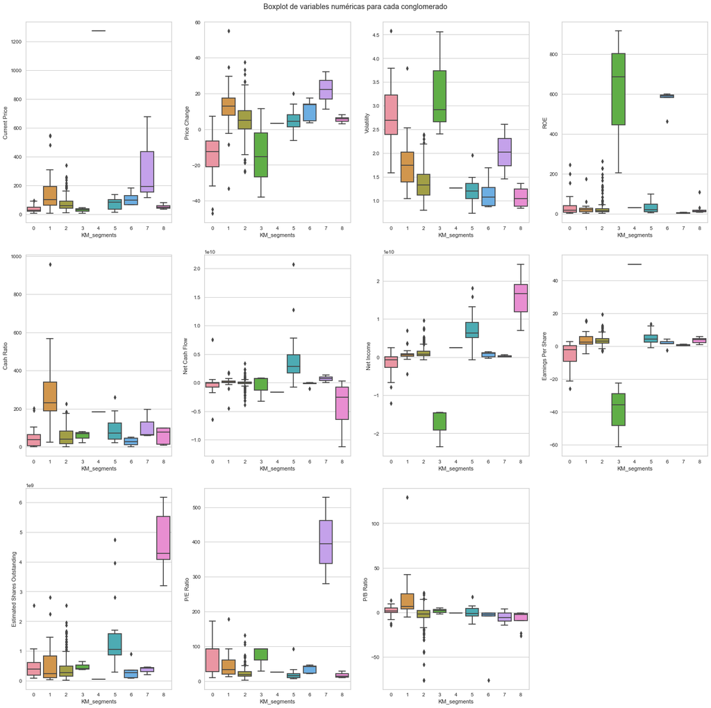

```python
plt.figure(figsize=(20, 20))
plt.suptitle("Boxplot de variables numéricas para cada conglomerado")

# selecting numerical columnsnum_col = df.select_dtypes(include=np.number).columns.tolist()

for i, variable in enumerate(num_col):
    plt.subplot(3, 4, i + 1)
    sns.boxplot(data=df1, x="KM_segments", y=variable)

plt.tight_layout(pad=2.0)
```

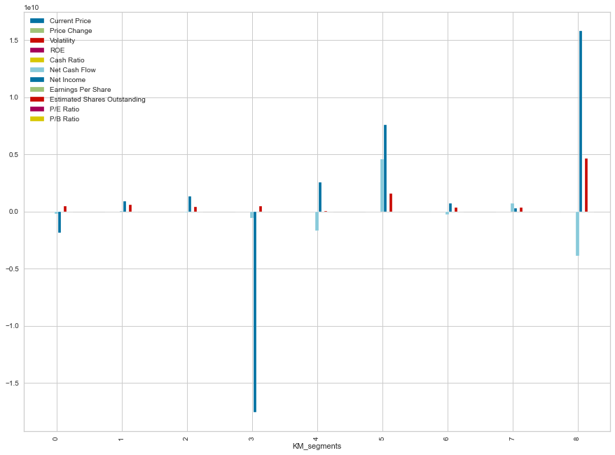

```python
df1.groupby("KM_segments").mean().plot.bar(figsize=(15,11))
```